# Uncertainty and Monte Carlo

Lecture 08

September 24, 2025

# Review of Last Classes

## Simulation

- “Mimic” data generation given a certain model for the relevant processes;
- Often requires some type of discretization (not always!)

## Simulation Workflow

[figure not shown]

Simulation Workflow

## Simulation

- “Mimic” data generation given a certain model for the relevant processes;
- Often requires some type of discretization (not always!)
- More complex approaches (*e.g.* discrete-event simulation) for specific use cases.

## Calibration and Validation

- **Calibration**: How do we select parameter values?
- **Validation**: Does the model adequately reproduce the system dynamics?

## Questions?

[figure not shown]

**Text**: VSRIKRISH to 22333

**URL**: https://pollev.com/vsrikrish  
[See Results](https://www.polleverywhere.com/multiple_choice_polls/qKeig0hHShZYHAOmvZtZm?preview=true&controls=none)

# Uncertainty and Systems Analysis

## Systems and Uncertainty

- *Deterministic models*: uncertainty due to the separation between the “internals” of the system and the “external” environment.
- *Stochastic models*: additional uncertainty from internal stochasticity

[figure not shown]

Conceptual Schematic of a Systems Model

## Uncertainty and Models

Uncertainty can come from:

- Stochastic models;
- Uncertain external conditions (forcings);
- Uncertain parameters;
- Uncertain model dynamics.

[figure not shown]

Conceptual Schematic of a Systems Model

## Types of Uncertainty

Two (broad) types of uncertainties:

- **Aleatory** uncertainty, or uncertainties resulting from randomness;
- **Epistemic** uncertainty, or uncertainties resulting from lack of knowledge.

[figure not shown]

Source: [XKCD 2440](https://xkcd.com/2440/)

# Probability

## Axioms of Probability

Probability is a language for expressing uncertainty.

The **axioms of probability** are straightforward:

1. $E$ is some “event”: $\mathcal{P}(E) \geq 0$;
2. $\Omega$ is the total event space: $\mathcal{P}(\Omega) = 1$;
3. $\mathcal{P}(\cup_{i=1}^\infty E_i) = \sum_{i=1}^\infty \mathcal{P}(E_i)$ for disjoint (or “independent”) $E_i$

## Probability Distributions

Probability distributions associate a probability to every event under consideration (the *event space*) and have to follow these axioms.

## Key Features of Probability Distributions

- Mean/Mode (what events are “typical”)
- Skew (are larger or smaller events more or equally probable)
- Variance (how spread out is the distribution around the mode)
- Tail Probabilities (how probable are extreme events)

## Common Distributions

- Gaussian / Normal
- Lognormal
- Binomial
- Uniform / Discrete Uniform

## Probability Density Function

A continuous distribution $\mathcal{D}$ has a probability density function (PDF) $f_\mathcal{D}(x) = p(x | \theta)$.

The probability of $x$ occurring in an interval $(a, b)$ is
$$\mathbb{P}[a \leq x \leq b] = \int_a^b f_\mathcal{D}(x)dx.$$

**Important**: $\mathbb{P}(x = x^*)$ is zero!

## Probability Mass Functions

Discrete distributions have *probability mass functions* (PMFs) which are defined at point values, e.g. $p(x = x^*) \neq 0$.

## Cumulative Density Functions

If $\mathcal{D}$ is a distribution with PDF $f_\mathcal{D}(x)$, the **cumulative density function** (CDF) of $\mathcal{D}$ is $F_\mathcal{D}(x)$:

$$F_\mathcal{D}(x) = \int_{-\infty}^x f_\mathcal{D}(u)du.$$

[figure not shown]

(a) Relationship of CDF and PDF

[figure not shown]

(b)

Figure 1

## Relationship Between PDFs and CDFs

Since
$$F_\mathcal{D}(x) = \int_{-\infty}^x f_\mathcal{D}(u)du,$$

if $f_\mathcal{D}$ is continuous at $x$, the Fundamental Theorem of Calculus gives:
$$f_\mathcal{D}(x) = \frac{d}{dx}F_\mathcal{D}(x).$$

## Quantiles

The quantile function is the **inverse of the CDF**:

$$q(\alpha) = F^{-1}_\mathcal{D}(\alpha)$$

So
$$x_0 = q(\alpha) \iff \mathbb{P}_\mathcal{D}(X < x_0) = \alpha.$$

[figure not shown]

(a) Relationship of CDF and PDF

[figure not shown]

(b)

Figure 2

## Distributions Are Assumptions

**Specifying a distribution is making an assumption about observations and any applicable constraints.**

Examples: If your observations are…

- Continuous and fat-tailed? **Cauchy distribution**
- Continuous and bounded? **Beta distribution**
- Sums of positive random variables? **Gamma or Normal distribution**.

## Selecting a Distribution

A distribution implicitly answers questions like:

- What is the most probable event? How much more likely is it than the others?
- Are larger or smaller events more, less, or equally probable?
- How probable are extreme events?
- Are different events correlated, or are they independent?

## Probability Distribution Tails

The tails of distributions represent the probability of high-impact outcomes.

**Key consideration**: Small changes to these (low) probabilities can greatly influence risk.

[figure not shown]

Figure 3: Comparison of Cauchy and Normal tails

## “What Distribution Should I Use?”

**There is no right answer to this, no matter what a statistical test tells you.**

- What assumptions are justifiable?
  - Particularly: think about tails, symmetry/skew
- What information do you have?

## “What Distribution Should I Use?”

For example, suppose our data are counts of events:

- If you know something about **rates**, you can use a Poisson distribution
- If you know something about **probabilities**, you can use a Binomial distribution.

## Conditional Probabilities

We often don’t want to just know if a particular event $A$ has a certain probability, but also how other events (call them $B$) might depend on that outcome.

**In other words:**

We want the *conditional probability* of $B$ given $A$, denoted $\mathbb{P}(B|A)$.

## Conditional Probabilities

We can write conditional probabilities in terms of unconditional probabilities:

$$\mathbb{P}(B|A) = \frac{\mathbb{P}(BA)}{\mathbb{P}(A)}.$$

# Monte Carlo

## Stochastic Simulation

**Monte Carlo simulation**: Propagating random samples through a model to estimate a value (usually an expectation or a quantile).

[figure not shown]

## Goals of Monte Carlo

Monte Carlo is a broad method, which can be used to:

1. Obtain probability distributions of outputs;
2. Estimate deterministic quantities.

## Monte Carlo Simulation

**Goal**: Estimate $\mathbb{E}_f\left[h(x)\right]$, $x \sim f(x)$

**Monte Carlo principle**:

- Sample $x^1, x^2, \ldots, x^N \sim f(x)$
- Estimate
  $$\mathbb{E}_f\left[h(x)\right] = \int_{x \in X} h(x)f(x)dx \approx \frac{1}{N} \sum_{n=1}^N h(x^n)$$

## MC Example: Finding $\pi$

How can we use MC to estimate $\pi$?

**Hint**: Think of $\pi$ as an expected value…

## MC Example: Finding $\pi$

Finding $\pi$ by sampling random values from the unit square and computing the fraction in the unit circle. This is an example of **Monte Carlo integration**.

$$\frac{\text{Area of Circle}}{\text{Area of Square}} = \frac{\pi}{4}$$

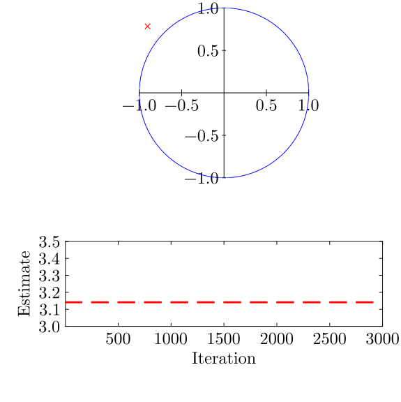

Figure 4: Monte Carlo simualtion for Estimating pi

## MC Example: Dice

What is the probability of rolling 4 dice for a total of 19?

Can simulate dice rolls and find the frequency of 19s among the samples.

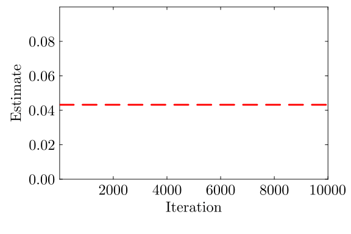

Figure 5: Monte Carlo simualtion for Dice Rolls

## MC Estimate of Quantiles

Would like to estimate the CDF $F$ with some approximation $\hat{F}_n$, then compute $\hat{z}^\alpha_n = \hat{F}_n^{-1}(\alpha)$ as an estimator of the $\alpha$-quantile $z^\alpha$.

Given samples $\hat{\mathbf{y}} = y_1, \ldots, y_n \sim F$, define
$$\hat{F}_n(y) = \frac{1}{n} \sum_{i=1}^n \mathbb{I}(y_i \leq y)$$
and $\hat{z}^\alpha_n = \hat{F}_n^{-1}(\alpha)$.

## Monte Carlo Estimation

This type of estimation can be repeated with any simulation model that has a stochastic component.

For example, consider our dissolved oxygen model. Suppose that we have a probability distribution for the inflow DO.

**How could we compute the probability of DO falling below the regulatory standard somewhere downstream?**

## Monte Carlo and Uncertainty Propagation

1. Draw samples from some distribution;
2. Run them through one or more models;
3. Compute the (conditional) probability of outcomes of interest (for good or bad).

# Key Takeaways

## Key Takeaways

- Systems analysis features many uncertainties, which may be neglected with certain methods/model setups.
- Risk: Combination of hazard, exposure, vulnerability, and response.
- Choice of probability distribution can have large impacts on uncertainty and risk estimates: **try not to use distributions just because they’re convenient.**
- **Monte Carlo**: Estimate expected values of outcomes using simulation.

# Upcoming Schedule

## Next Classes

**Monday**: Monte Carlo Lab (clone before class, maybe instantiate environment too)

**Wednesday**: Why Does Monte Carlo Work?